# Practical Learning Machine Project

Carlos Cortes Franco

Sunday, June 21, 2015

## Background

Using devices such as Jawbone Up, Nike FuelBand, and Fitbit it is now possible to collect a large amount of data about personal activity relatively inexpensively. These type of devices are part of the quantified self movement - a group of enthusiasts who take measurements about themselves regularly to improve their health, to find patterns in their behavior, or because they are tech geeks. One thing that people regularly do is quantify how much of a particular activity they do, but they rarely quantify how well they do it. In this project, your goal will be to use data from accelerometers on the belt, forearm, arm, and dumbell of 6 participants. They were asked to perform barbell lifts correctly and incorrectly in 5 different ways. More information is available from the website here: http://groupware.les.inf.puc-rio.br/har (see the section on the Weight Lifting Exercise Dataset).

## Data

The training data for this project are available here: https://d396qusza40orc.cloudfront.net/predmachlearn/pml-training.csv The test data are available here: https://d396qusza40orc.cloudfront.net/predmachlearn/pml-testing.csv

The data for this project come from this source: http://groupware.les.inf.puc-rio.br/har.

## Loading the data

```r
#{r Block1, cache = TRUE}
setwd("C:/GitHub/PLM")
url <- "http://d396qusza40orc.cloudfront.net/predmachlearn/pml-training.csv"
dfile <- "C:/GitHub/PLM/pml-training.csv"
if(!file.exists(dfile)) {
        download.file(url, dfile)
}
train_raw <- read.csv(dfile,na.strings=c("NA","","#DIV/0!"))
url <- "http://d396qusza40orc.cloudfront.net/predmachlearn/pml-testing.csv"
dfile <- "C:/GitHub/PLM/pml-testing.csv"
if(!file.exists(dfile)) {
        download.file(url, dfile)
}
test_raw <- read.csv(dfile,na.strings=c("NA","","#DIV/0!"))
```

## Cleaning the datasets

```r
# Removing columns with NA
train_clean <- train_raw[!sapply(train_raw,function(z)any(is.na(z)))]
test_clean  <- test_raw[!sapply(test_raw,function(z)any(is.na(z)))]

# Eliminating non important columns
train_total <- train_clean[,-c(1:7)]
test_total  <- test_clean[,-c(1:7)]
```

## Data analysis

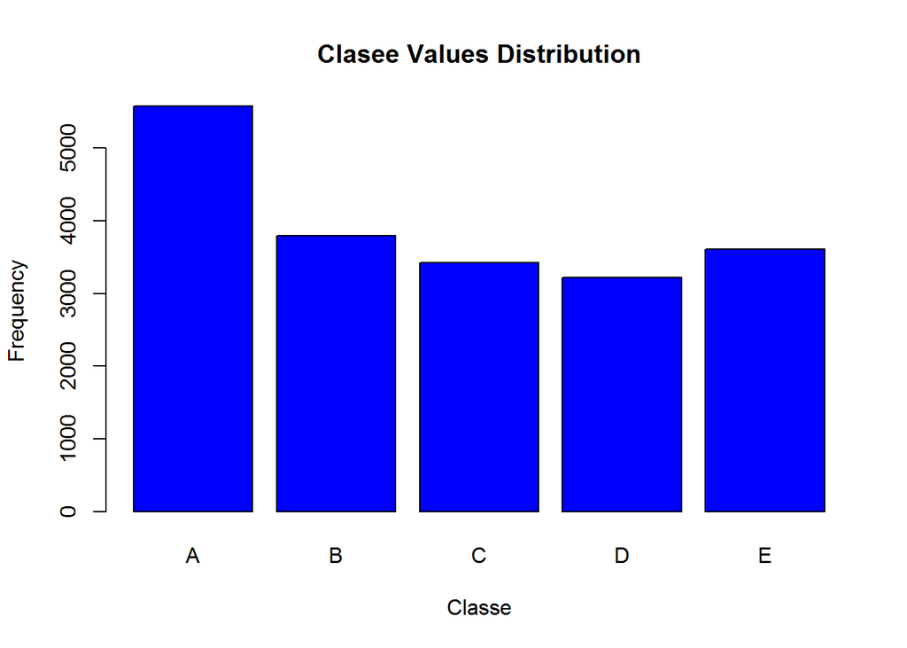

```r
# Check Classe Frequency distribution
plot(train_total$classe, col="blue", main="Clasee Values Distribution", xlab="Classe", ylab="Frequency")
```

```r
table(train_total$classe)
```

```
##
##    A    B    C    D    E
## 5580 3797 3422 3216 3607
```

## Partition the training dataset

```r
library(caret)
# Partition the training dataset
inTrain <- createDataPartition(y=train_total$classe, p=0.7, list=FALSE)
train <- train_total[inTrain,]
test  <- train_total[-inTrain,]
```

## Model training for lda and random forest

```r
modFit_lda <- train(classe ~. , data=train, method="lda")
library(randomForest)
modFit_rf  <- randomForest(classe ~. , data=train, method="class")
```

## Comparing accuracies of both methods

```r
predict_lda <- predict(modFit_lda, test)
print(confusionMatrix(predict_lda, test$classe))
```

```
## Confusion Matrix and Statistics
##
##           Reference
## Prediction    A    B    C    D    E
##          A 1361  162  115   44   30
##          B   44  749   83   44  185
##          C  137  135  691  132  115
##          D  123   37  118  709   96
##          E    9   56   19   35  656
##
## Overall Statistics
##
##                Accuracy : 0.7079
##                  95% CI : (0.6961, 0.7195)
##     No Information Rate : 0.2845
##     P-Value [Acc > NIR] : < 2.2e-16
##
##                   Kappa : 0.6306
##  Mcnemar's Test P-Value : < 2.2e-16
##
## Statistics by Class:
##
##                      Class: A Class: B Class: C Class: D Class: E
## Sensitivity            0.8130   0.6576   0.6735   0.7355   0.6063
## Specificity            0.9166   0.9250   0.8932   0.9240   0.9752
## Pos Pred Value         0.7950   0.6778   0.5711   0.6547   0.8465
## Neg Pred Value         0.9250   0.9184   0.9283   0.9469   0.9166
## Prevalence             0.2845   0.1935   0.1743   0.1638   0.1839
## Detection Rate         0.2313   0.1273   0.1174   0.1205   0.1115
## Detection Prevalence   0.2909   0.1878   0.2056   0.1840   0.1317
## Balanced Accuracy      0.8648   0.7913   0.7833   0.8297   0.7908
```

```r
predict_rf <- predict(modFit_rf, test)
print(confusionMatrix(predict_rf, test$classe))
```

```
## Confusion Matrix and Statistics
##
##           Reference
## Prediction    A    B    C    D    E
##          A 1672    6    0    0    0
##          B    2 1131    8    0    0
##          C    0    2 1014    9    2
##          D    0    0    4  951    1
##          E    0    0    0    4 1079
##
## Overall Statistics
##
##                Accuracy : 0.9935
##                  95% CI : (0.9911, 0.9954)
##     No Information Rate : 0.2845
##     P-Value [Acc > NIR] : < 2.2e-16
##
##                   Kappa : 0.9918
##  Mcnemar's Test P-Value : NA
##
## Statistics by Class:
##
##                      Class: A Class: B Class: C Class: D Class: E
## Sensitivity            0.9988   0.9930   0.9883   0.9865   0.9972
## Specificity            0.9986   0.9979   0.9973   0.9990   0.9992
## Pos Pred Value         0.9964   0.9912   0.9873   0.9948   0.9963
## Neg Pred Value         0.9995   0.9983   0.9975   0.9974   0.9994
## Prevalence             0.2845   0.1935   0.1743   0.1638   0.1839
## Detection Rate         0.2841   0.1922   0.1723   0.1616   0.1833
## Detection Prevalence   0.2851   0.1939   0.1745   0.1624   0.1840
## Balanced Accuracy      0.9987   0.9954   0.9928   0.9927   0.9982
```

## Showing the most important variables

```r
varImp <- varImp(modFit_rf)
varImp_rnames <- rownames(varImp)
vars <- order(varImp, decreasing = TRUE)
vI <- data.frame(variable = varImp_rnames[vars], importance = varImp[vars,])
head(vI)
```

```
##            variable importance
## 1         roll_belt   878.5470
## 2          yaw_belt   600.0531
## 3     pitch_forearm   530.2666
## 4 magnet_dumbbell_z   528.1493
## 5 magnet_dumbbell_y   473.6369
## 6        pitch_belt   468.1863
```

## Predicting for the test dataset with the best method

```r
#predict(modFit_lda, newdata=test_total)
predict(modFit_rf,  newdata=test_total)
```

```
##  1  2  3  4  5  6  7  8  9 10 11 12 13 14 15 16 17 18 19 20
##  B  A  B  A  A  E  D  B  A  A  B  C  B  A  E  E  A  B  B  B
## Levels: A B C D E
```

## Writing the answer files

```r
answers <- as.vector(predict(modFit_rf,  newdata=test_total))

pml_write_files = function(x) {
    n = length(x)
    for (i in 1:n) {
        filename = paste0("problem_id_", i, ".txt")
        write.table(x[i], file = filename, quote = FALSE, row.names = FALSE,
            col.names = FALSE)
    }
}

pml_write_files(answers)
```